# Polygenic burden and environmental sensitivity

Author

Gibran Hemani

## Background

We performed MR analysis of main effects on variance effects for a trait, where the variance effects come from the MZ GWAS and the main effects come from published studies. We found that higher main effects for depression associated with larger MZ variance effects for depression in adults but not in children.

How to interpret this?

- This association can arise under the null when only the main effects were present (no variance effects)
- Higher polygenic burden leads to greater environmental sensitivity through GxE interactions

## Simulation

### Data generating model

Simulate a polygenic score for MZ pair $i$ as

$$s_i = \sum_{k=1}^M \beta_k g_{ik}$$

Then generate the depression liability for MZ pair $i$ individual $j$

$$l_{ij} = \beta_1 s_i + \beta_2 s_i e_{ij} + \epsilon_{ij}$$

A depression binary variable is then generated as

$$y_{ij} = \text{Bernoulli}(\text{logit}^{-1}(l_{ij}))$$

### Estimation

For each SNP $k$ obtain the effect estimate $\hat{\beta}_k$ from the first individual from each MZ pair. Then estimate the MZ difference effect as

$$| l_{i1} - l_{i2} | = \hat{\alpha} + \hat{\beta}_{2k} g_{ik} + \epsilon_{i}$$

Simularly $\hat{\beta}_{1k}$ can be estimated through logistic regression of $y_{i1}$ on $g_{i1}$.

## Results

```r
nsnp <- 100
n <- 10000
beta2 <- 0.1
h2 <- 0.4

sim <- function(nsnp, n, beta2, h2) {
  G <- matrix(
    rbinom(nsnp * n, 2, 0.5),
    nrow = n,
    ncol = nsnp
  )
  beta1 <- rnorm(nsnp)
  prs <- scale(G %*% beta1) %>% drop()
  prs <- prs * 0.2 + 0.5
  prs[prs < 0] <- 0
  # v1 <- rnorm(n, 0, beta2 * prs)
  # v2 <- rnorm(n, 0, beta2 * prs)
  e1 <- rnorm(n)
  e2 <- rnorm(n)
  r1 <- rnorm(n, 0, sqrt(1 - h2))
  r2 <- rnorm(n, 0, sqrt(1 - h2))
  l1 <- prs + beta2 * prs * e1 + r1
  l2 <- prs + beta2 * prs * e2 + r2
  y1 <- rbinom(n, 1, plogis(l1))
  y2 <- rbinom(n, 1, plogis(l2))
  return(list(
    phen=tibble(y1, y2, l1, l2, prs),
    beta1 = beta1,
    G=G
  ))
}
```

```r
test_logistc <- function(G, y1) {
  for(i in 1:ncol(G)) {
    m <- glm(y1 ~ G[,i], family=binomial)$coef[2]
  }
}

test_mz <- function(G, y1, y2) {
  yd1 <- abs(y1-y2)
  lapply(1:ncol(G), \(i) {
    fast_assoc(yd1, G[,i]) %>%
      as_tibble() %>%
      mutate(method="mzdiff")
  }) %>%
    bind_rows()
}
```

```r
param <- expand.grid(
  nsnp = 100,
  n = 25000,
  beta2 = c(0, 0, 0, seq(0, 0.2, by=0.02)),
  h2 = 0.7,
  rep=1:50
)

sim_test <- function(nsnp, n, beta2, h2, rep=1) {
  args <- list(nsnp=nsnp, n=n, beta2=beta2, h2=h2, rep=rep) %>% as_tibble()
  a <- sim(nsnp, n, beta2, h2)
  res <- test_mz(a$G, a$phen$l1, a$phen$l2)
  mod <- summary(lm(a$beta1 ~ 0 + res$bhat, weight = 1 / res$se^2))
  args$estimate <- mod$coefficients[1,1]
  args$se <- mod$coefficients[1,2]
  args$p <- mod$coefficients[1,4]
  return(args)
}

simres <- furrr::future_pmap(param, sim_test, .options=furrr_options(seed=TRUE)) %>%
  bind_rows()
saveRDS(simres, file="simres.rds")
```

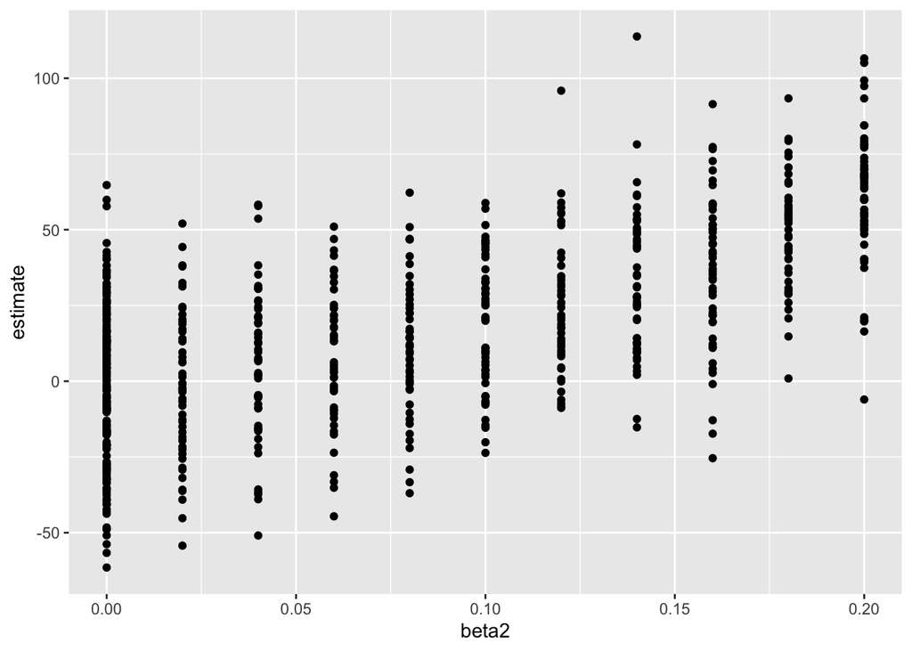

```r
ggplot(simres, aes(x=beta2, y=estimate)) +
  geom_point()
```

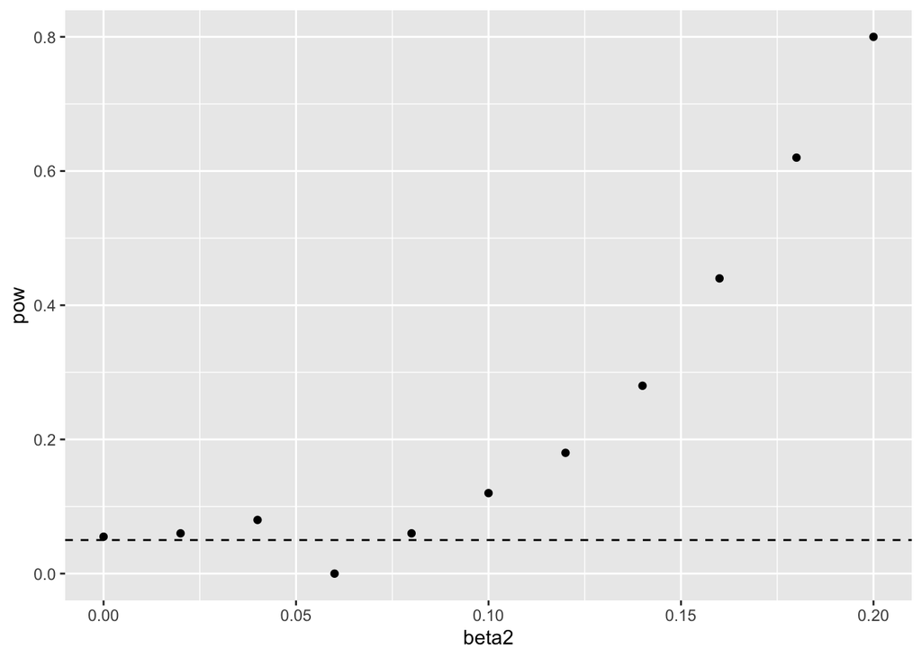

```r
group_by(simres, beta2) %>%
  summarise(
    n=n(),
    mean=mean(estimate),
    se=mean(se),
    pow=sum(p < 0.05)/n()
  ) %>%
  ggplot(aes(x=beta2, y=pow)) +
  geom_point() +
  geom_hline(yintercept=0.05, linetype="dashed")
```

## Summary

- Type I error is well controlled for this data generating model.
- The straightforward ‘causal’ interpretation here is that higher disease liability increases environmental sensitivity. That mechanism of environmental sensitivity is that a polygenic GxE interaction is recapitulated by the MR framework of main effects on variance effects
- This is demonstrating that there are MZ variance effects that are likely undetectable at GWAS significance thresholds but are revealed when hypothesising that there are variance effects at the main effects. Essentially it’s a mechanism to improve power to detect evidence of vQTL
- It also suggests that if this is GxE then it isn’t locus specific, which is what the GWAS ostensibly does. It is an interaction with a latent genetic risk factor. There could be interesting locus specific vQTLs.
- Showing that this manifests in adults and not in children makes it a bit more robust and has implications for the aetiology of disease.